# Project 2

Jasmine Gallaway 10-14-2023

## Beginner Friendly Havard Art Museum API Query

So you like art. You like the art that is in the Harvard Art Museum. You want to know the numbers and data behind the art in the museum. The Harvard Art Museum API is the resource for you. This vignette is the resource to make your API data dive easier!

There’s many parts to obtaining the data from an API. Typically a URL must be made to call the API, the returned data will need to be parsed into a readable format, and then sort and clean the data to uncover your perfect dataset. For coding beginners this may seem like a daunting task; however, this vignette will guide you through the steps- starting with what packages you need downloaded.

### Necessary Libraries

This whole vignette was accomplished with a few installed packages. Those packages are:

- `httr` to call the API
- `jsonlite` to make the JSON API output more readable in R
- `dplyr` to manipulate data
- `tidyverse` to transform and present data
- `ggplot2` to make graphics
- `cowplot` to put plots on a grid for visual comparison

## How to Query the Harvard Art API

After reading in those libraries the next step is to code your query! In my experience, making sure the syntax on the API call is correct can be a lot when starting out. Good thing that the Harvard Art Museum API is very beginner friendly! There is plenty of good documentation to explain the database so figuring out what resources or filters to use isn’t so difficult. To make the process more simple I have created multiple functions to go through the call, parsing, and filtering of data from an API. So after you sign up for an API key on the Harvard Art Museum API website, feel free to try out these helpful functions.

### Homemade Functions

`composing_URL`

In this function the inputs are “resource”, “filtering”, and “key”. All three of these inputs must to be entered as a character string with quotes around the option. `composing_URL` will return one of two base URL formats to access the API. These base URLs can be made unique with the multitude of options for the arguments.

```r
#This function will return the URL to use to access the correct API endpoint
composing_URL <- function(resource, key, filtering = "na"){
  my_URL <- if(filtering != "na"){
    paste0("https://api.harvardartmuseums.org/",resource,"?q=",filtering,"&apikey=",key)}
    else{
    paste0("https://api.harvardartmuseums.org/",resource,"&apikey=",key)
    }
  return(my_URL)
}
```

`more_pages`

In case you need more data for your uses, I created a pagination function to help ease the process of gathering more information from the Harvard Art Museum API. This API does have a limit of 10,000 entries per API key so be wise in how you are grabbing data. The input includes your base URL, where you want to set your limit at (the default is 100 so you don’t query all in one spot, remember 10,000 is the limit set by the API and you cannot change that), and how many items you would like to see on each page.

```r
#This is what my best attempt at the pagination function would be. In my attempts to merge it with my other functions I decided to simply add a &size= to the URL calls so that I could get enough data. I changed the size of the functions that I use in my EDA to higher numbers so that I could get the graphs that I wanted
#A while loop is a good fit to watch your limits. It only works while a condition is true.
more_pages <- function(my_URL, limit = 100, items_per_page = 10){
  #Setting up all other variables for this function
  #Setting this at zero for when you begin to query
  items_received <- 0

  #This variable is telling R what page we are on
  on_page <- 1

  #Here is the conditional while loop
  while (items_received < limit){
  #Creating another with page number in the URL
  page_URL <- paste0(my_URL, "?page=", on_page)


  #Getting data from the URL
  response <- httr::GET(page_URL)

  #Saving the items on the page
  items <- httr::content(response)[["items"]]

  #Adding the number of new items to the total items received so far
  items_received <- items_received + length(items)

  #Tracking what page of data it is on
  on_page <- on_page + 1
  }

  #Letting the user know how many items they have called for from the API
  return(items_received)
}
```

`object_info`

If you’re a little lost in where to start your search I have also made some other functions to query more specific endpoints of the Harvard Art Museum API. `object_info` is one of the resources in this API is “object” which gives more information about the artwork, artist, online view count, and even what medium was used. The purpose of this function is to access the object ID, what century it is from, what culture it is from, and the total online page views. The object ID is included in this tibble in case you would like to remember a specific object to call for later on. The only input is your personal API key and the end result should be a table of object information.

```r
#Calling the API for object, information
object_info <- function(key){
  #Providing the base URL
  base_URL <- "https://api.harvardartmuseums.org/object?apikey="

  #Pasting together the API
  object_URL <- paste0(base_URL, key,"&size=200")

  #Pulling data from the API
  my_data <- httr::GET(object_URL)

  #Turning data into a table that is readable in R
  readable_table <- fromJSON(rawToChar(my_data$content))

  #Picking out the objectid, century, culture, and totalpageviews
  selected_table <- select(readable_table$records, objectid, century, culture, totalpageviews)

  #Printing out the table a little nicer as a tibble
  informational_table <- as_tibble(selected_table)

  #Remove rows with NA
  informational_table <- na.omit(informational_table)

  #Returning the informational table }
  print(informational_table)
}
```

`cultured_objects`

This function is to call to the API for more information about the objects, but only selecting a particular culture of objects to look at. Some options that the Harvard Art Museum API has is American, Coptic, Byzantine, and Japanese. The only necessary input is your API key and the culture name which should be specified in quotations.

```r
#Calling the API for objects from a specific culture
cultured_objects <- function(key, culture){
  #Providing the base URL
  base_URL <- "https://api.harvardartmuseums.org/object?apikey="

  #Pasting together the API
  cult_obj_URL <- paste0(base_URL,key,"&q=culture:",culture,"&size=50")

  #Pulling data from the API
  my_data <- httr::GET(cult_obj_URL)

  #Turning data into a table that is readable in R
  readable_table <- fromJSON(rawToChar(my_data$content))

  #Picking out the objectid, century, culture to assure you received the correct information, and totalpageviews
  selected_table <- select(readable_table$records, objectid, century, culture, totalpageviews)

  #Printing out the table a little nicer as a tibble
  informational_table <- as_tibble(selected_table)

  #Remove rows with NA
  informational_table <- na.omit(informational_table)

  #Returning the informational table
  print(informational_table)
}
```

`century_objects`

Maybe you’re more of a history buff, and you would like to only learn about objects from your favorite century. `century_objects` function can help you out! The input need for this function is your API key and which century you would like to look at. Century should be in the format of: “14th century BCE” or “6th millennium BCE”.

```r
#Calling the API for objects from different centuries
century_objects <- function(key, century){
  #Providing the base URL
  base_URL <- "https://api.harvardartmuseums.org/object?apikey="

  #Pasting together the API
  cent_obj_URL <- paste0(base_URL,key,"&q=century:",century,"&size=50")

  #Pulling data from the API
  my_data <- httr::GET(cent_obj_URL)

  #Turning this into a table that is readable in R
  readable_table <- fromJSON(rawToChar(my_data$content))

  #Picking out the objectid, century to assure correct information is received, culture, and totalpageviews
  selected_table <- select(readable_table$records, objectid, century, culture, totalpageviews)

  #Printing out the table a little nicer as a tibble
  informational_table <- as_tibble(selected_table)

  #Remove rows with NA
  informational_table <- na.omit(informational_table)

  #Returning the informational table
  print(informational_table)
}
```

`find_people`

Are you more of a people person? If you would like to know more about the people behind the work `find_people` can introduce you to some information. In this function the person ID (like object ID this can be used to call information about a specific person later), binary gender, culture, object count (how many pieces from them), and the date they began to show the work are returned in a neat little table as a result.

```r
#Calling the API for people who have had something displayed at the Harvard Art Museum
find_people <- function(key){
    #Providing the base URL
  base_URL <- "https://api.harvardartmuseums.org/person?apikey="

  #Pasting together the API
  person_URL <- paste0(base_URL, key,"&size=200")

  #Pulling data from the API
  my_data <- httr::GET(person_URL)

  #Turning this into a table that is readable in R
  readable_table <- fromJSON(rawToChar(my_data$content))

  #Picking out the personid, displayname, gender, objectcount, and datebegin
  selected_table <- select(readable_table$records, personid, displayname, gender, objectcount, datebegin)

  #Printing out the table a little nicer as a tibble
  informational_table <- as_tibble(selected_table)

  #Remove rows with NA
  informational_table <- na.omit(informational_table)

  #Remove the rows with subset() to clean the data some
  pers_tbl <- subset(informational_table, (gender != "unknown" & objectcount != 0 & datebegin != 0))

  #Returning the good table
  return(pers_tbl)
}
```

`date_people`

This function allows the user to change the years that the `datebegin` looks at. In this function the user can specify `before` or `after` a `year_desired` so that the records of people will reflect this modification.

```r
#Calling the API for people who have had something displayed at the Harvard Art Museum
date_people <- function(key, when, year_desired){
  #Providing the base URL
  base_URL <- "https://api.harvardartmuseums.org/person?apikey="

  #Pasting together the API
  date_pers_URL <- paste0(base_URL, key,"&",when,"=",year_desired,"&size=50")

  #Pulling data from the API
  my_data <- httr::GET(date_pers_URL)

  #Turning this into a table that is readable in R
  readable_table <- fromJSON(rawToChar(my_data$content))

  #Picking out the personid, displayname, gender, objectcount, and datebegin
  selected_table <- select(readable_table$records, personid, displayname, gender, objectcount, datebegin)

  #Printing out the table a little nicer as a tibble
  informational_table <- as_tibble(selected_table)

  #Remove rows with NA
  informational_table <- na.omit(informational_table)

  #Remove the rows with subset() to clean the data some
  date_pers_tbl <- subset(informational_table, (gender != "unknown" & objectcount != 0 & datebegin != 0))

  #Returning the good table
  return(date_pers_tbl)
}
```

`person_gender`

My personal favorite would be this `person_gender` function. I could see a lot of good data analysis coming from comparing the male to female records in this binary gender option. The input here will be your API key and then selecting male or female to retrun all the male data or all the female data.

```r
#Calling the API for people based on a binary gender model
person_gender <- function(key, gender){
    #Providing the base URL
  base_URL <- "https://api.harvardartmuseums.org/person?apikey="

  #Pasting together the API
  gen_pers_URL <- paste0(base_URL,key,"&q=gender:",gender,"&size=200")

  #Pulling data from the API
  my_data <- httr::GET(gen_pers_URL)

  #Turning this into a table that is readable in R
  readable_table <- fromJSON(rawToChar(my_data$content))

  #Picking out the personid, displayname, gender (to assure correctness), objectcount, and datebegin
  selected_table <- select(readable_table$records, personid, displayname, gender, objectcount, datebegin)

  #Printing out the table a little nicer as a tibble
  informational_table <- as_tibble(selected_table)

  #Remove the rows with subset() to clean the data some
  gen_pers_tbl <- subset(informational_table, (gender != "unknown" & objectcount != 0 & datebegin != 0))

  #Returning the good table
  return(gen_pers_tbl)
}
```

## Go Wild for Expoloratory Data Analysis (EDA)

EDA is the most fun part of the API query journey! Now you can take whatever data you chose and figure out the different relationships between your specified options. Here I am going to analyze the difference between male and female records. I want to see which of these two genders appears more throughout time and how much each has. Commonly today we hear how men take up most of different spaces and I want to see if that applies to art at the museum as well. Do men hold the most space at museums? Is there any time when there were more obejcts from women than men? What is the average amount of object per man or woman?

```r
#Had to make one specifically for the first 200 female and 200 males entries separately because there is so much data, but each user has a limit of 10,000 and I am not trying to hit that.
#Using my person_gender function to pull in data for this numerical summary
fem_pers_tbl <- person_gender("1d505e26-5d36-4674-a35b-c40cab886778", "female")

#Doing the same for men
mal_pers_tbl <- person_gender("1d505e26-5d36-4674-a35b-c40cab886778", "male")

#Selecting the specific columns I want to look at so summarise() does not clutter the table
fem_gen_summary <- fem_pers_tbl %>%
              group_by(gender) %>%
              summarise(mean = mean(objectcount),
                       sd = sd(objectcount),
                       min = min(objectcount),
                       max = max(objectcount),
                       IQR = IQR(objectcount))

#Doing the same for the male statistics
mal_gen_summary <- mal_pers_tbl %>%
              group_by(gender) %>%
              summarise(mean = mean(objectcount),
                       sd = sd(objectcount),
                       min = min(objectcount),
                       max = max(objectcount),
                       IQR = IQR(objectcount))

#Printing the summaries table
print(fem_gen_summary)
```

```
## # A tibble: 1 × 6
##   gender  mean    sd   min   max   IQR
##   <chr>  <dbl> <dbl> <int> <int> <dbl>
## 1 female  4.78  12.8     1    81     2
```

```r
#Printing the male summaries table
print(mal_gen_summary)
```

```
## # A tibble: 1 × 6
##   gender  mean    sd   min   max   IQR
##   <chr>  <dbl> <dbl> <int> <int> <dbl>
## 1 male    12.5  21.6     1   120    13
```

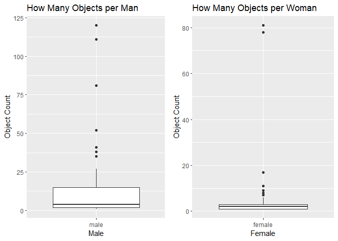

```r
#Making a boxplot of the summary statistics for a more visual look
mal_gen_plot1 <- ggplot(data = mal_pers_tbl, aes(x = gender, y = objectcount)) +
         geom_boxplot() +
         labs(title = "How Many Objects per Man", x = "Male", y = "Object Count")

#Making the womens objectcount summaries boxplot
fem_gen_plot1 <-ggplot(data = fem_pers_tbl, aes(x = gender, y = objectcount)) +
         geom_boxplot() +
         labs(title = "How Many Objects per Woman", x = "Female", y = "Object Count")

#Plotting the two plots side by side for better visual
plot_grid(mal_gen_plot1, fem_gen_plot1, ncol = 2)
```

These two boxplot show an interesting dynamic. Here we can see that the spread of how many object each male record has is larger than that of the female records. These numbers are further broken down in the numerical summaries of women (`fem_gen_summary`) and men (`mal_gen_summary`). In those numcerical summary tables women have on average a mean of about 4 objects and a maximum of 81 objects. In the men’s records, men have an average of about 12 objects and a maximum of 120 objects. These results are based off of about 200 of the entries for men and women each. To draw conclusions off of this small sample size, I would say that men take up more space than women in the Harvard Art Museum. Now these results do not address timing yet, but the sheer difference in average objects per man lead me to believe that men in general hold more space in the museum.

Next I want to address the time of when either gender is more popular. I made two contingency tables, one for each of the binary genders. In these tables I compared the frequency of the gender to each year recorded for `datebegin`. In the tables I expect to be abel to compare which year(s) were more popular for men or women based on the frequencies.

```r
#Still must pull both genders separately for better analysis
#Creating a contingency table for women and datebegin
fem_con_tbl_1 <- table(fem_pers_tbl$gender,
                  fem_pers_tbl$datebegin)

#Creating a contingency table for men and datebegin
mal_con_tbl_2 <- table(mal_pers_tbl$gender,
                  mal_pers_tbl$datebegin)

#Printing out the contingency table for women
print(fem_con_tbl_1)
```

```
##
##          1747 1820 1864 1876 1889 1891 1898 1900 1903 1907 1908 1912 1916 1922 1925 1926 1929 1930 1931 1933 1934 1935 1936 1937 1940 1941 1942 1943
##   female    1    1    1    1    1    1    2    8    1    1    2    1    1    1    3    2    1    2    2    1    2    2    1    1    1    6    3    1
##
##          1944 1945 1946 1950 1951 1952 1953 1954 1955 1957 1958 1960 1965 1990 1993
##   female    3    3    1    1    3    3    1    1    1    1    1    1    1    1    1
```

```r
#Printing out the contingency table for men
print(mal_con_tbl_2)
```

```
##
##        -100 1500 1743 1767 1800 1805 1809 1812 1819 1822 1830 1841 1843 1848 1858 1865 1872 1874 1880 1883 1887 1894 1906 1912 1914 1920 1926 1928
##   male    1    2    1    1    1    1    1    2    1    2    1    1    1    2    1    1    1    2    1    3    2    1    1    1    1    1    1    1
##
##        1931 1932 1934 1935 1938 1939 1940 1941 1942 1943 1944 1945 1946 1947 1948 1949 1950 1951 1952 1953 1955 1956 1964 1966 1968 1969 1970 1976
##   male    2    2    2    2    2    1    1    1    1    2    2    1    1    3    2    2    1    1    1    1    2    1    1    2    1    1    1    1
##
##        1978 1979
##   male    1    1
```

In the `mal_con_tbl_2` the most popular `datebegin` is in 1883 and 1947 with both of these years having a total of 3 men beginning then. In the `fem_con_tbl_1` table women had the most starts in 1900, and 1941, with a total of 8 and 6, respectively. This is very interesting that women had more concentrated starts than men did. I would be very intrigued to figure out which records of women started during these time and what made this occur. These contingency tables are not the best as entries are removed due to NA values in other columns. Not all of the years are listed on both contingency tables so it is difficult to officially compare and draw conclusions. The only year with a high start date is in 1941. In 1941 there were 6 women who started, compared to 1 man. Further data analysis is required to see which binary gender is more popular throughout each year.

The next contingency table is one that compares the culture to the century. In this table, I should be able to see what century the work from a specific culture comes from. This is important to answer questions about the spread of culture throughout time.

```r
#Using the object_info function to pull data for the contingency table
obj_tbl <- object_info("1d505e26-5d36-4674-a35b-c40cab886778")
```

```
## # A tibble: 100 × 4
##    objectid century      culture totalpageviews
##       <int> <chr>        <chr>            <int>
##  1   161783 20th century German?              2
##  2   161784 20th century German?              2
##  3   161785 20th century German?              5
##  4   161786 20th century German?              4
##  5   161787 20th century German?              2
##  6   161788 20th century German?              2
##  7   161789 20th century German?              5
##  8   161790 20th century German?              2
##  9   161791 20th century German?              2
## 10   161792 20th century German?              2
## # ℹ 90 more rows
```

```r
#Creating a contingency table for culture and century
con_tbl_3 <- table(obj_tbl$culture,
                  obj_tbl$century)
#Printing out the contingency table
print(con_tbl_3)
```

```
##
##            20th century
##   American           64
##   German              5
##   German?            31
```

The results of the `con_tbl_3` were slightly disappointing. In adhereing to my API request limit of a sample size of 200 at any given time, not too much of the data could be pulled from the API. This table resulted in showing that American and German work was taken from the 20th century. While the contingency table did what it was supposed to, my small sample size halted deep analysis of all cultures over time.

Next, I made line plots of both binary genders to see the spread of their object counts over time. Essentially I wanted a visual display of the contingency table with the object counts throughout the different `datebegin` entries. This plot should show me when either gender was more popular and how many objects were from each year. I already know that men have on average more objects than women, but I would like to see the spread over the years. I expect the men to cover a longer range of time than women.

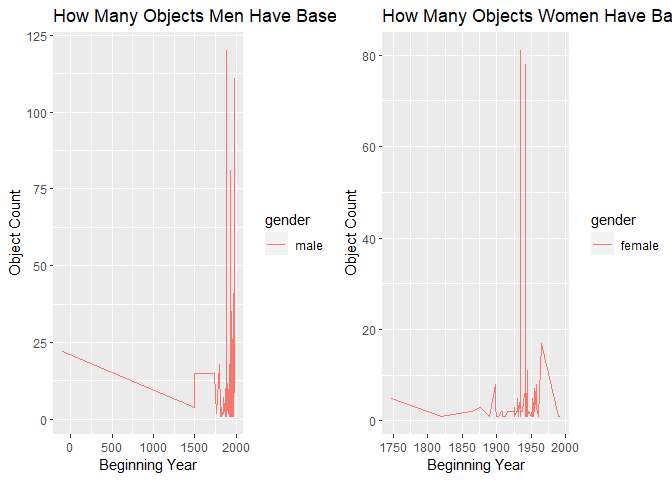

```r
#Both of the binary genders must be pulled separately due to the low sample sizes.
#Making a line plot off of the objectcount over time for men
mal_obj_cnt_plot2 <- ggplot(mal_pers_tbl, aes(x = datebegin, y = objectcount, color = gender)) +
            geom_line() +
            labs(title = "How Many Objects Men Have Based on Beginning Date", x = "Beginning Year", y = "Object Count")

#Making a line plot off of the objectcount over time for women
fem_obj_cnt_plot2 <- ggplot(fem_pers_tbl, aes(x = datebegin, y = objectcount, color = gender)) +
            geom_line() +
            labs(title = "How Many Objects Women Have Based on Beginning Date", x = "Beginning Year", y = "Object Count")

#Printing the two graphs side by side for better comparison
plot_grid(mal_obj_cnt_plot2, fem_obj_cnt_plot2, ncol = 2)
```

These line plots show some interesting results. While the line plots might have a better scale if they were separated, together they show some interesting trends. As seen in the `mal_con_tbl_2` there is an interest data point that shows a male record containing a -100 `datebegin` value. I am uncertain of what this value is for, but it should be removed for better data analysis. In the male line plot above, the range truly starts around the 1500s compared to the female line plot starting around 1750. Due to the one outlier point, the male line plot is more difficult to see, but the bulk of the graph is in the 1750-2000 range like the female plot. Further research will be needed to see which record created the male outliers. The female line plot shows that women were most popular to start around the 1940s, as also seen in the female contingency table.

Now I want to change gears a little and look at some other data more about the objects and how often they are viewed. What culture is the most viewed? When pulling from different cultures is this done over a large or more concentrated amount of time? Questions like these can be answered by using the object API calls. Here I create a column plot which is similar to a histogram or bar plot, but this plot handles a discrete variable of x and a continuous variable of y to better suit my data. The column plot compares the total number of online views to each century. My guess would be that more recent pieces would be more popular.

```r
#Including the call again so that the plots render correctly
obj_tbl3 <- object_info("1d505e26-5d36-4674-a35b-c40cab886778")
```

```
## # A tibble: 99 × 4
##    objectid century           culture  totalpageviews
##       <int> <chr>             <chr>             <int>
##  1     5132 20th century      American             22
##  2     5133 20th century      American             20
##  3     5134 20th century      American             19
##  4     5135 20th century      American             17
##  5     5136 19th-20th century British              28
##  6     5137 19th-20th century French              112
##  7     5138 20th century      American              9
##  8     5139 19th-20th century French               45
##  9     5140 19th century      French               73
## 10     5141 19th century      French               26
## # ℹ 89 more rows
```

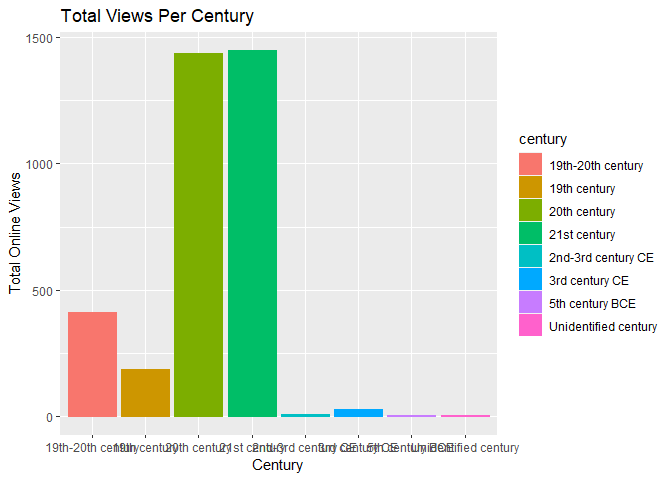

```r
#Make a scatterplot of the century versus the totalpageviews
cent_views_plot3 <- ggplot(obj_tbl3, aes(x = century, y = totalpageviews)) +
                             geom_col(aes(fill = century, color = century)) +
                             labs(title = "Total Views Per Century", x = "Century", y = "Total Online Views")
#Returning the plot
cent_views_plot3
```

Similar to before, I want to see the most viewed culture of the objects. My assumption would be that more commonly known cultures, i.e. Japanese over Coptic, would be viewed more than lesser known options. It would be interesting to see among the popular ones which culture comes out with the most views. I would imagine that cultures rich in history and artistic skill would have more than other cultures. I am not a history buff, otherwise I might be able to name which ones would be my top guesses for the most viewed culture.

```r
#Including the call again so that the plots render correctly
obj_tbl4 <- object_info("1d505e26-5d36-4674-a35b-c40cab886778")
```

```
## # A tibble: 100 × 4
##    objectid century      culture totalpageviews
##       <int> <chr>        <chr>            <int>
##  1   161783 20th century German?              2
##  2   161784 20th century German?              2
##  3   161785 20th century German?              5
##  4   161786 20th century German?              4
##  5   161787 20th century German?              2
##  6   161788 20th century German?              2
##  7   161789 20th century German?              5
##  8   161790 20th century German?              2
##  9   161791 20th century German?              2
## 10   161792 20th century German?              2
## # ℹ 90 more rows
```

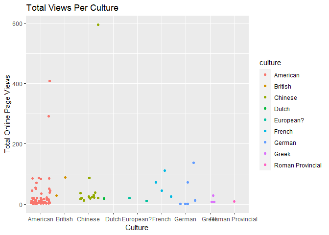

```r
#Make a histogram for the totalpageviews per culture
cult_views_plot4 <- ggplot(obj_tbl3, aes(x = culture, y = totalpageviews)) +
                              geom_jitter(aes(fill = culture, color = culture)) +
                              labs(title = "Total Views Per Culture", x = "Culture", y = "Total Online Page Views")
#Returning the plot
cult_views_plot4
```

```r
#Including the call again so that the plots render correctly
obj_tbl <- object_info("1d505e26-5d36-4674-a35b-c40cab886778")
```

```
## # A tibble: 100 × 4
##    objectid century      culture totalpageviews
##       <int> <chr>        <chr>            <int>
##  1   161783 20th century German?              2
##  2   161784 20th century German?              2
##  3   161785 20th century German?              5
##  4   161786 20th century German?              4
##  5   161787 20th century German?              2
##  6   161788 20th century German?              2
##  7   161789 20th century German?              5
##  8   161790 20th century German?              2
##  9   161791 20th century German?              2
## 10   161792 20th century German?              2
## # ℹ 90 more rows
```

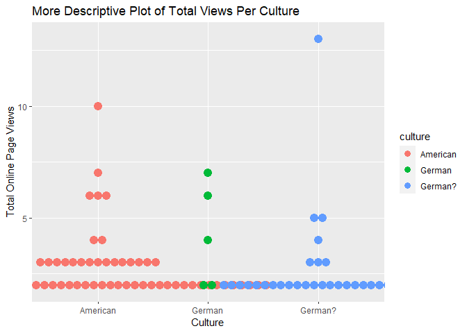

```r
#Make a dotplot to demonstrate the totalpageviews per culture
cult_views_plot5.5 <- ggplot(obj_tbl, aes(x = culture, y = totalpageviews)) +
                              geom_dotplot(aes(fill = culture, color = culture), binaxis = "y", stackdir = "center") +
                              labs(title = "More Descriptive Plot of Total Views Per Culture", x = "Culture", y = "Total Online Page Views")
#Returning the plot
cult_views_plot5.5
```